# Exponential Distribution Simulations

Gabe Rudy

April 19, 2015

In this project, we will investigate through simulations the properties of the mean of samples of the exponential distribution.

The properties we are investigating are:

1. Sample mean versus the theoretical distribution mean
2. The sample variance versus the theoritcal distribution variance
3. The distribution of these means versus the normal distribution

The exponential distribution has a $\lambda$ parameter. We will also need to choose how many samples we will be taking from this distribution $n$. Finally the number of simulations will be $nosim$.

For this exercise we will set:

```r
lambda <- 0.2
n <- 40
nosim <- 1000
```

## Sample Mean versus Theoretical Mean

Lets investigate the sample mean first. We take $nosim$ draws of $n$ samples from the exponential distribution with `rexp` and take the mean of each.

The population mean is $1/\lambda$ that we are comparing to.

```r
sim_means <- replicate(nosim, { mean(rexp(n, rate=lambda)) })
population_mean <- 1/lambda

c(mean(sim_means), population_mean)
```

```
## [1] 5.03253 5.00000
```

The first number is mean of our `sim_means`, which is very close to the second number, the `population_mean`.

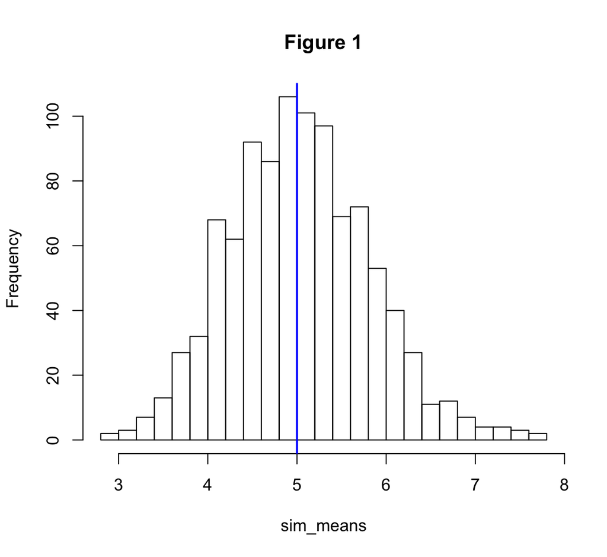

In **Figure 1** we show its distribution with the population mean of `5` drawn in a blue line. Note how close it is to the normal distribution. More on that in Distribution.

## Sample Variance versus Theoretical Variance

Now for investigating the sample variance we can compute the variance of our simulated means. From the *Central Limit Therom* we know the variance of the sample mean will be $\sigma^2/n$. The standard deviation ($\sigma$) of the exponential distribution is $1/\lambda$.

```r
sample_var <- var(sim_means)
population_var <- ((1/lambda)^2)/n
population_sd <- sqrt(population_var)

c(sample_var, population_var)
```

```
## [1] 0.6224973 0.6250000
```

## Distribution

Let’s compare our sample `sim_means` to $nosim$ random normals with the `mean` and `sd` parameters set to the values we have shown we expect of `population_mean` and `population_sd`.

```r
sim_normals <- rnorm(nosim, mean=population_mean, sd=population_sd)
```

Now let’s compare the histogram of `sim_means` to our `sim_normals`.

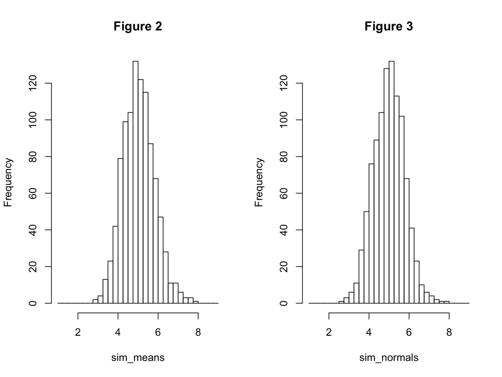

As expected by the *Central Limit Therom*, the means of our random exponential random variable in **Figure 2** are dstributed normally. **Figure 3** shows for comparison the same number of random variables taken from the normal distribution with the therom provided parameters.